# hw2

Name: Sonia Thomas github username: sthomas20

2/4/2020

This homework is about syntax and basic plotting functions in R, and is **due by the end of Feb 7**.

You can use the RMarkDown file with these homework instructions as a template for your work. Make sure to replace “Your Name” and “your_github_username” in the YAML with your name and Github username.

**Submission instructions**: Create a folder named `ds202_hw2`, and name the RMarkDown file including your solutions `hw2.Rmd` under this folder. For submission, create a GitHub repository named `ds202_hw2` under your account, and push both `hw2.Rmd` and the knitted `hw2.html` to GitHub before the deadline. I will assume you use the same GitHub username as for your HW1 submission. The latest version of your homework appearing on GitHub before the deadline is graded. *It is crucial to follow the exact folder structure and file names*, so that your homework can be reproduced and graded by an automated script. Some questions will require the following answer format.

## R commands

### Question 1

1. Today’s temperature has a high of 24 and a low of 15 degree fahrenheit. Find the corresponding degress in celsius and storage it in a (single) vector named `cel`. Print the variable.

```r
temp<- c(24,15)
temp
```

```
## [1] 24 15
```

```r
convert_fahr_to_cels <- function(temp) {
  celsius <- 5/9 * (temp - 32)

  return(celsius)
}

cel<- convert_fahr_to_cels(temp)
cel
```

```
## [1] -4.444444 -9.444444
```

### Question 2

2. Create a vector of length 200. The odd entries should be 3 and even entries should be 1. Storage the created in a variable named `vec200` and print.

```r
vec200<- c(1:200)
for (i in 1:200)
{
  if((i %% 2) == 0) {
    vec200[i]<- 1
  }
  else {
    vec200[i]<- 3
  }

}
 print(vec200)
```

```
##   [1] 3 1 3 1 3 1 3 1 3 1 3 1 3 1 3 1 3 1 3 1 3 1 3 1 3 1 3 1 3 1 3 1 3 1 3 1 3
##  [38] 1 3 1 3 1 3 1 3 1 3 1 3 1 3 1 3 1 3 1 3 1 3 1 3 1 3 1 3 1 3 1 3 1 3 1 3 1
##  [75] 3 1 3 1 3 1 3 1 3 1 3 1 3 1 3 1 3 1 3 1 3 1 3 1 3 1 3 1 3 1 3 1 3 1 3 1 3
## [112] 1 3 1 3 1 3 1 3 1 3 1 3 1 3 1 3 1 3 1 3 1 3 1 3 1 3 1 3 1 3 1 3 1 3 1 3 1
## [149] 3 1 3 1 3 1 3 1 3 1 3 1 3 1 3 1 3 1 3 1 3 1 3 1 3 1 3 1 3 1 3 1 3 1 3 1 3
## [186] 1 3 1 3 1 3 1 3 1 3 1 3 1 3 1
```

### Question 3

3. How many perfect squares are there between 1 and 2001? Storage the answer in a variable named `numPerfect` and print. You may want to look at `?round`.

```r
range <- c(1:2001)
numPerfect <- 0

for(i in range){
  square_root = sqrt(i)
  if (square_root %% 1 == 0){
    numPerfect <- numPerfect + 1
  }
}

print(numPerfect)
```

```
## [1] 44
```

## Cars and mileage

For this part we will use the `mpg` data set, you can access the data by first installing (using `install.packages('ggplot2')`) and then loading the package `ggplot2` (using `library(ggplot2)`) into your R session. The `mpg` data includes information about fuel economy of popular car models for the years 1999 and 2008 as collected by the US Environmental Protection Agency. An answer should include a short paragraph of text for the explanation to a (human) reader, together with appropriate R code, outputs, and graphs.

Most exercises are from the ggplot2 book section 2.2.1. You might find it helpful for working on the homework to read through this section. *However, all questions can be solved by using just the basic R graphics functions.*

### Question 1

1. What are the 3 most fuel-efficient models in terms of highway mileage? Storage the data frame (with 3 rows) containing all information of these three cars in a variable named `top3` and print.

```r
summary(mpg)
```

```
##  manufacturer          model               displ            year
##  Length:234         Length:234         Min.   :1.600   Min.   :1999
##  Class :character   Class :character   1st Qu.:2.400   1st Qu.:1999
##  Mode  :character   Mode  :character   Median :3.300   Median :2004
##                                        Mean   :3.472   Mean   :2004
##                                        3rd Qu.:4.600   3rd Qu.:2008
##                                        Max.   :7.000   Max.   :2008
##       cyl           trans               drv                 cty
##  Min.   :4.000   Length:234         Length:234         Min.   : 9.00
##  1st Qu.:4.000   Class :character   Class :character   1st Qu.:14.00
##  Median :6.000   Mode  :character   Mode  :character   Median :17.00
##  Mean   :5.889                                         Mean   :16.86
##  3rd Qu.:8.000                                         3rd Qu.:19.00
##  Max.   :8.000                                         Max.   :35.00
##       hwy             fl               class
##  Min.   :12.00   Length:234         Length:234
##  1st Qu.:18.00   Class :character   Class :character
##  Median :24.00   Mode  :character   Mode  :character
##  Mean   :23.44
##  3rd Qu.:27.00
##  Max.   :44.00
```

```r
head(mpg)
```

```
## # A tibble: 6 x 11
##   manufacturer model displ  year   cyl trans      drv     cty   hwy fl    class
##   <chr>        <chr> <dbl> <int> <int> <chr>      <chr> <int> <int> <chr> <chr>
## 1 audi         a4      1.8  1999     4 auto(l5)   f        18    29 p     compa…
## 2 audi         a4      1.8  1999     4 manual(m5) f        21    29 p     compa…
## 3 audi         a4      2    2008     4 manual(m6) f        20    31 p     compa…
## 4 audi         a4      2    2008     4 auto(av)   f        21    30 p     compa…
## 5 audi         a4      2.8  1999     6 auto(l5)   f        16    26 p     compa…
## 6 audi         a4      2.8  1999     6 manual(m5) f        18    26 p     compa…
```

```r
three<- sort(mpg$hwy, decreasing = TRUE)[1:3]
three
```

```
## [1] 44 44 41
```

```r
top3 <- mpg[mpg$hwy %in% c(41, 44), ]
top3
```

```
## # A tibble: 3 x 11
##   manufacturer model   displ  year   cyl trans   drv     cty   hwy fl    class
##   <chr>        <chr>   <dbl> <int> <int> <chr>   <chr> <int> <int> <chr> <chr>
## 1 volkswagen   jetta     1.9  1999     4 manual… f        33    44 d     compact
## 2 volkswagen   new be…   1.9  1999     4 manual… f        35    44 d     subcom…
## 3 volkswagen   new be…   1.9  1999     4 auto(l… f        29    41 d     subcom…
```

##### **The three most fuel-effiecient models in terms of highway mileage are the volkwagen jetta and the new beetle based on the data from above.**

### Question 2

2. How many different compact models are included in this dataset? Storage the answer in a variable named `numCompact` and print.

```r
head(mpg)
```

```
## # A tibble: 6 x 11
##   manufacturer model displ  year   cyl trans      drv     cty   hwy fl    class
##   <chr>        <chr> <dbl> <int> <int> <chr>      <chr> <int> <int> <chr> <chr>
## 1 audi         a4      1.8  1999     4 auto(l5)   f        18    29 p     compa…
## 2 audi         a4      1.8  1999     4 manual(m5) f        21    29 p     compa…
## 3 audi         a4      2    2008     4 manual(m6) f        20    31 p     compa…
## 4 audi         a4      2    2008     4 auto(av)   f        21    30 p     compa…
## 5 audi         a4      2.8  1999     6 auto(l5)   f        16    26 p     compa…
## 6 audi         a4      2.8  1999     6 manual(m5) f        18    26 p     compa…
```

```r
compact <- mpg[which(mpg$class == "compact"),]
compact
```

```
## # A tibble: 47 x 11
##    manufacturer model    displ  year   cyl trans   drv     cty   hwy fl    class
##    <chr>        <chr>    <dbl> <int> <int> <chr>   <chr> <int> <int> <chr> <chr>
##  1 audi         a4         1.8  1999     4 auto(l… f        18    29 p     comp…
##  2 audi         a4         1.8  1999     4 manual… f        21    29 p     comp…
##  3 audi         a4         2    2008     4 manual… f        20    31 p     comp…
##  4 audi         a4         2    2008     4 auto(a… f        21    30 p     comp…
##  5 audi         a4         2.8  1999     6 auto(l… f        16    26 p     comp…
##  6 audi         a4         2.8  1999     6 manual… f        18    26 p     comp…
##  7 audi         a4         3.1  2008     6 auto(a… f        18    27 p     comp…
##  8 audi         a4 quat…   1.8  1999     4 manual… 4        18    26 p     comp…
##  9 audi         a4 quat…   1.8  1999     4 auto(l… 4        16    25 p     comp…
## 10 audi         a4 quat…   2    2008     4 manual… 4        20    28 p     comp…
## # … with 37 more rows
```

```r
numCompact<-length(unique(compact$model))
print(numCompact)
```

```
## [1] 8
```

##### **Based on the output above there are 8 different compact models.**

### Question 3

3. Create a scatterplot of `hwy` and `cty` and describe the relationship. Why are there so few points visible? Explain your findings.

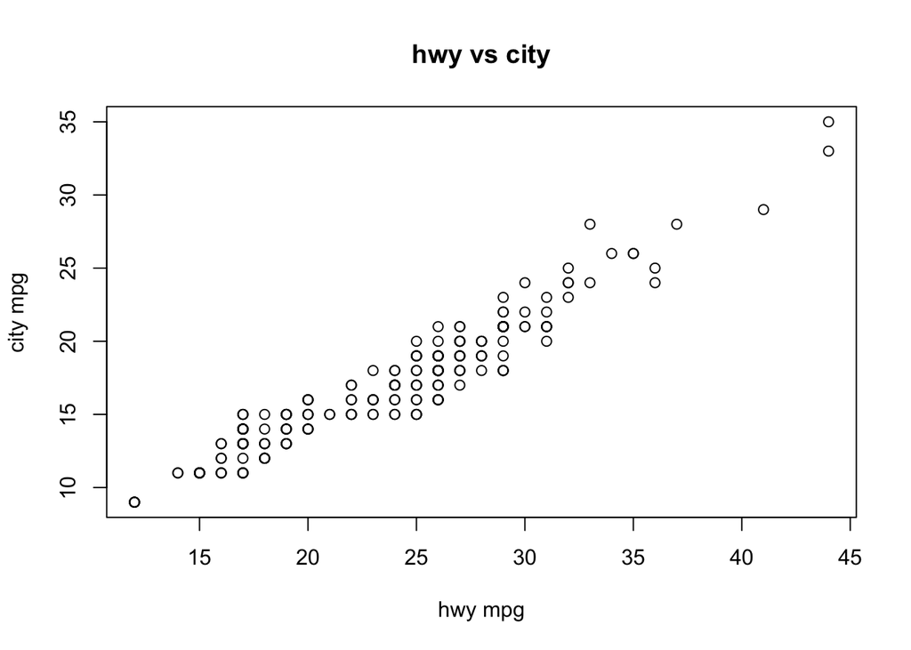

```r
x<-mpg$hwy
y<-mpg$cty
plot(x,y, main= "hwy vs city", xlab = "hwy mpg", ylab = "city mpg",)
```

##### **Based on the scatter plot there seems to be a positive linear relationship and correlation between the two variables, cty and hwy. There are few visible points because if you look closer at the graph the darker the circle is that means it is representing a duplicate of that point so thats why there is so little points. When in reality there should be over 200 observations based on the dataset and thats why there doesn’t seem to be over 200 plotted points on the graph.**

### Question 4

4. Are cars in 2008 more fuel efficient than cars in 1999? Use graphs *and* summary statistics to answer this question. Explain your findings.

```r
cars2008<- mpg[mpg$year == 2008, ]
cars2008
```

```
## # A tibble: 117 x 11
##    manufacturer model     displ  year   cyl trans  drv     cty   hwy fl    class
##    <chr>        <chr>     <dbl> <int> <int> <chr>  <chr> <int> <int> <chr> <chr>
##  1 audi         a4          2    2008     4 manua… f        20    31 p     comp…
##  2 audi         a4          2    2008     4 auto(… f        21    30 p     comp…
##  3 audi         a4          3.1  2008     6 auto(… f        18    27 p     comp…
##  4 audi         a4 quatt…   2    2008     4 manua… 4        20    28 p     comp…
##  5 audi         a4 quatt…   2    2008     4 auto(… 4        19    27 p     comp…
##  6 audi         a4 quatt…   3.1  2008     6 auto(… 4        17    25 p     comp…
##  7 audi         a4 quatt…   3.1  2008     6 manua… 4        15    25 p     comp…
##  8 audi         a6 quatt…   3.1  2008     6 auto(… 4        17    25 p     mids…
##  9 audi         a6 quatt…   4.2  2008     8 auto(… 4        16    23 p     mids…
## 10 chevrolet    c1500 su…   5.3  2008     8 auto(… r        14    20 r     suv
## # … with 107 more rows
```

```r
cars1999<- mpg[mpg$year == 1999,]
cars1999
```

```
## # A tibble: 117 x 11
##    manufacturer model     displ  year   cyl trans  drv     cty   hwy fl    class
##    <chr>        <chr>     <dbl> <int> <int> <chr>  <chr> <int> <int> <chr> <chr>
##  1 audi         a4          1.8  1999     4 auto(… f        18    29 p     comp…
##  2 audi         a4          1.8  1999     4 manua… f        21    29 p     comp…
##  3 audi         a4          2.8  1999     6 auto(… f        16    26 p     comp…
##  4 audi         a4          2.8  1999     6 manua… f        18    26 p     comp…
##  5 audi         a4 quatt…   1.8  1999     4 manua… 4        18    26 p     comp…
##  6 audi         a4 quatt…   1.8  1999     4 auto(… 4        16    25 p     comp…
##  7 audi         a4 quatt…   2.8  1999     6 auto(… 4        15    25 p     comp…
##  8 audi         a4 quatt…   2.8  1999     6 manua… 4        17    25 p     comp…
##  9 audi         a6 quatt…   2.8  1999     6 auto(… 4        15    24 p     mids…
## 10 chevrolet    c1500 su…   5.7  1999     8 auto(… r        13    17 r     suv
## # … with 107 more rows
```

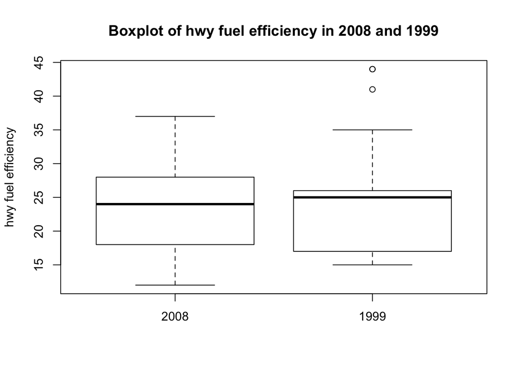

```r
x2<-cars2008$hwy
y2<-cars1999$hwy
boxplot(x2, y2, main= "Boxplot of hwy fuel efficiency in 2008 and 1999", ylab = "hwy fuel efficiency", names = c("2008", "1999"))
```

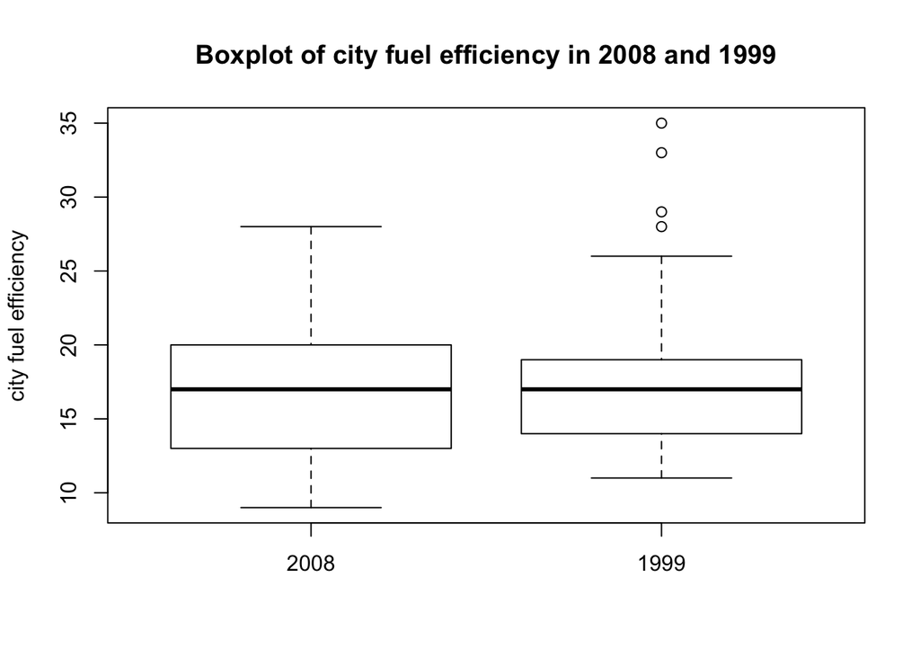

```r
x3<-cars2008$cty
y3<-cars1999$cty
boxplot(x3, y3, main= "Boxplot of city fuel efficiency in 2008 and 1999", ylab = "city fuel efficiency", names = c("2008", "1999"))
```

```r
#summary of hwy fuel efficiency in 2008
summary(x2)
```

```
##    Min. 1st Qu.  Median    Mean 3rd Qu.    Max.
##   12.00   18.00   24.00   23.45   28.00   37.00
```

```r
#summary of hwy fuel efficiency in 1999
summary(y2)
```

```
##    Min. 1st Qu.  Median    Mean 3rd Qu.    Max.
##   15.00   17.00   25.00   23.43   26.00   44.00
```

```r
#summary of city fuel efficiency in 2008
summary(x3)
```

```
##    Min. 1st Qu.  Median    Mean 3rd Qu.    Max.
##     9.0    13.0    17.0    16.7    20.0    28.0
```

```r
#summary of city fuel efficiency in 1999
summary(y3)
```

```
##    Min. 1st Qu.  Median    Mean 3rd Qu.    Max.
##   11.00   14.00   17.00   17.02   19.00   35.00
```

Note: your submission is supposed to be fully reproducible, i.e. the TA and I will ‘knit’ your submission. Make sure that you don’t use any file structure that depends on your computing environment.